# ARIMA VLKAF PREDICTION

[figure not shown]

##### Gdańsk University of Technology

### Project Lead: dr Paweł Weichbroth

### Authors:

- Dariusz Kobiela
- Dawid Krefta
- Weronika Król

```python
import pandas as pd
from matplotlib import pyplot as plt
import numpy as np
import statsmodels.api as sm
```

```python
df = pd.read_csv("VLKAFmonthlyprepared.csv", sep=";")
df
```

|  | timestamp | price |
| --- | --- | --- |
| 0 | 31.10.2008 | 1000 |
| 1 | 28.11.2008 | 1000 |
| 2 | 30.12.2008 | 513,5 |
| 3 | 28.01.2009 | 306 |
| 4 | 20.02.2009 | 117,75 |
| ... | ... | ... |
| 148 | 26.02.2021 | 364,5 |
| 149 | 31.03.2021 | 389,95 |
| 150 | 30.04.2021 | 346,13 |
| 151 | 28.05.2021 | 317 |
| 152 | 30.06.2021 | 253,5 |

153 rows × 2 columns

```python
#change commas to dots
df = df.apply(lambda x: x.str.replace(',','.'))
df
```

|  | timestamp | price |
| --- | --- | --- |
| 0 | 31.10.2008 | 1000 |
| 1 | 28.11.2008 | 1000 |
| 2 | 30.12.2008 | 513.5 |
| 3 | 28.01.2009 | 306 |
| 4 | 20.02.2009 | 117.75 |
| ... | ... | ... |
| 148 | 26.02.2021 | 364.5 |
| 149 | 31.03.2021 | 389.95 |
| 150 | 30.04.2021 | 346.13 |
| 151 | 28.05.2021 | 317 |
| 152 | 30.06.2021 | 253.5 |

153 rows × 2 columns

```python
df.columns
```

```
Index(['timestamp', 'price'], dtype='object')
```

```python
df.dtypes
```

```
timestamp    object
price        object
dtype: object
```

```python
df.DATA = pd.to_datetime(df.DATA)
```

```python
df.price = pd.to_numeric(df.price, downcast="float")
```

```python
df.dtypes
```

[output not shown]

```python
df.columns = ["timestamp", "value"]
df.columns
```

```
Index(['timestamp', 'value'], dtype='object')
```

```python
df
```

|  | timestamp | value |
| --- | --- | --- |
| 0 | 31.10.2008 | 1000.000000 |
| 1 | 28.11.2008 | 1000.000000 |
| 2 | 30.12.2008 | 513.500000 |
| 3 | 28.01.2009 | 306.000000 |
| 4 | 20.02.2009 | 117.750000 |
| ... | ... | ... |
| 148 | 26.02.2021 | 364.500000 |
| 149 | 31.03.2021 | 389.950012 |
| 150 | 30.04.2021 | 346.130005 |
| 151 | 28.05.2021 | 317.000000 |
| 152 | 30.06.2021 | 253.500000 |

153 rows × 2 columns

```python
df
```

|  | timestamp | value |
| --- | --- | --- |
| 0 | 31.10.2008 | 1000.000000 |
| 1 | 28.11.2008 | 1000.000000 |
| 2 | 30.12.2008 | 513.500000 |
| 3 | 28.01.2009 | 306.000000 |
| 4 | 20.02.2009 | 117.750000 |
| ... | ... | ... |
| 148 | 26.02.2021 | 364.500000 |
| 149 | 31.03.2021 | 389.950012 |
| 150 | 30.04.2021 | 346.130005 |
| 151 | 28.05.2021 | 317.000000 |
| 152 | 30.06.2021 | 253.500000 |

153 rows × 2 columns

### TODO: set y ticks as dates

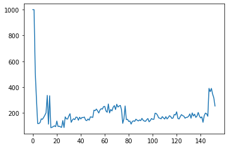

```python
df['value'].plot()
```

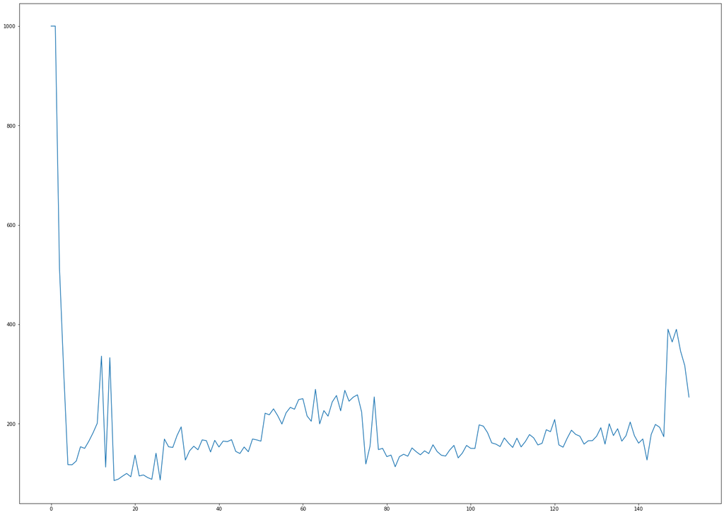

```python
plt.figure(figsize=(26, 19))
plt.plot(df.index, df.value)
plt.show()
```

## SERIES DECOMPOSITION

```python
from pylab import rcParams
rcParams['figure.figsize'] = 18, 8
decomposition = sm.tsa.seasonal_decompose(df.timestamp, model='additive')
fig = decomposition.plot()
plt.show()
```

[output not shown]

### Logarytm zmiennej

```python
df['log_value'] = np.log(df['value'])
```

```python
df
```

|  | timestamp | value | log_value |
| --- | --- | --- | --- |
| 0 | 31.10.2008 | 1000.000000 | 6.907755 |
| 1 | 28.11.2008 | 1000.000000 | 6.907755 |
| 2 | 30.12.2008 | 513.500000 | 6.241250 |
| 3 | 28.01.2009 | 306.000000 | 5.723585 |
| 4 | 20.02.2009 | 117.750000 | 4.768564 |
| ... | ... | ... | ... |
| 148 | 26.02.2021 | 364.500000 | 5.898527 |
| 149 | 31.03.2021 | 389.950012 | 5.966019 |
| 150 | 30.04.2021 | 346.130005 | 5.846815 |
| 151 | 28.05.2021 | 317.000000 | 5.758902 |
| 152 | 30.06.2021 | 253.500000 | 5.535364 |

153 rows × 3 columns

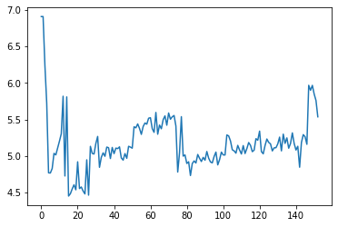

```python
#Zmieniły się wartości na osi OY, a więc i wahania (zmieniła się skala)
df.log_value.plot()
```

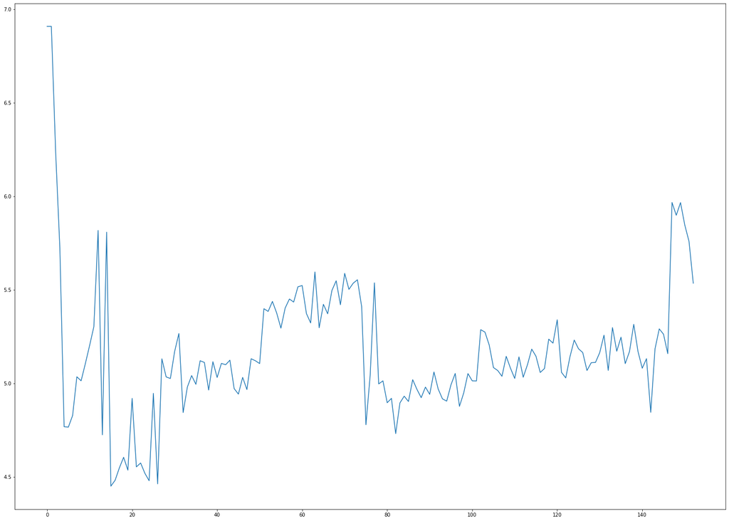

```python
plt.figure(figsize=(26, 19))
plt.plot(df.index, df.log_value)
plt.show()
```

Na wykresie możemy zaobserwować wahania stochastyczne - błądzenie przypadkowe bez dryfu (oscyluje wokół stałej wartości - 5.0). A więc jest stała, nie ma trendu. “c” : constant only (default). https://www.statsmodels.org/stable/generated/statsmodels.tsa.stattools.adfuller.html

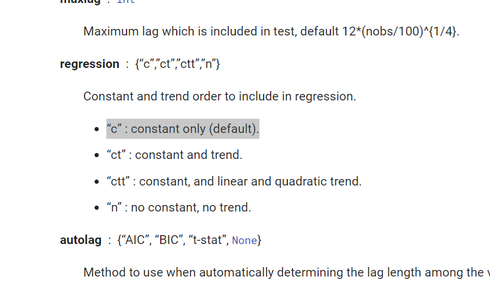

## ANALIZA STACJONARNOŚCI - graficznie

#### ACF and PACF

```python
df['log_value'].values
```

```
array([6.9077554, 6.9077554, 6.24125  , 5.723585 , 4.7685637, 4.7664385,
       4.828314 , 5.035328 , 5.013963 , 5.1059456, 5.202632 , 5.3033047,
       5.817303 , 4.725173 , 5.8081427, 4.450853 , 4.4824376, 4.5485997,
       4.6051702, 4.536356 , 4.919981 , 4.553877 , 4.574711 , 4.5196123,
       4.479957 , 4.9469852, 4.4630303, 5.1313767, 5.034677 , 5.0261807,
       5.170484 , 5.2665687, 4.8441873, 4.9810348, 5.041811 , 4.9951153,
       5.120992 , 5.1119876, 4.9645915, 5.1158957, 5.031744 , 5.106854 ,
       5.0998664, 5.123964 , 4.972241 , 4.9428487, 5.0320706, 4.967293 ,
       5.1316724, 5.120983 , 5.1059756, 5.3990674, 5.3847246, 5.4380794,
       5.3764353, 5.295313 , 5.4026775, 5.4509525, 5.434595 , 5.5162473,
       5.52306  , 5.373332 , 5.32301  , 5.59564  , 5.297149 , 5.422524 ,
       5.3720326, 5.496758 , 5.5482974, 5.420535 , 5.5880723, 5.502482 ,
       5.5353637, 5.5537343, 5.409635 , 4.7791233, 5.043425 , 5.5373344,
       4.9972124, 5.013631 , 4.89672  , 4.919981 , 4.731803 , 4.895823 ,
       4.9317365, 4.9034214, 5.019925 , 4.9681454, 4.923842 , 4.980176 ,
       4.9416423, 5.0610113, 4.9698133, 4.917423 , 4.905275 , 4.9921317,
       5.0530562, 4.8774085, 4.94876  , 5.052417 , 5.01383  , 5.012966 ,
       5.2871046, 5.2740245, 5.204995 , 5.084567 , 5.0689044, 5.0379586,
       5.144481 , 5.081404 , 5.026443 , 5.141605 , 5.0330486, 5.0999274,
       5.183187 , 5.1451664, 5.0584726, 5.079415 , 5.236442 , 5.215153 ,
       5.339939 , 5.0591717, 5.0293264, 5.1427155, 5.23159  , 5.1853166,
       5.164786 , 5.0689044, 5.110692 , 5.112108 , 5.164786 , 5.257704 ,
       5.0692186, 5.2983174, 5.1719036, 5.247024 , 5.105703 , 5.170484 ,
       5.315666 , 5.170484 , 5.081094 , 5.1321154, 4.8453674, 5.1843085,
       5.291343 , 5.2629495, 5.159055 , 5.9667873, 5.8985267, 5.9660187,
       5.8468146, 5.7589016, 5.5353637], dtype=float32)
```

```python
del df["value"]
df
```

|  | timestamp | log_value |
| --- | --- | --- |
| 0 | 31.10.2008 | 6.907755 |
| 1 | 28.11.2008 | 6.907755 |
| 2 | 30.12.2008 | 6.241250 |
| 3 | 28.01.2009 | 5.723585 |
| 4 | 20.02.2009 | 4.768564 |
| ... | ... | ... |
| 148 | 26.02.2021 | 5.898527 |
| 149 | 31.03.2021 | 5.966019 |
| 150 | 30.04.2021 | 5.846815 |
| 151 | 28.05.2021 | 5.758902 |
| 152 | 30.06.2021 | 5.535364 |

153 rows × 2 columns

```python
df.log_value.squeeze()
```

```
0      6.907755
1      6.907755
2      6.241250
3      5.723585
4      4.768564
         ...
148    5.898527
149    5.966019
150    5.846815
151    5.758902
152    5.535364
Name: log_value, Length: 153, dtype: float32
```

## ACF and PACF

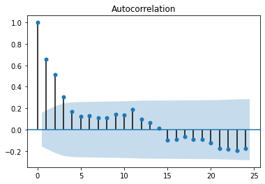

```python
#POPRAWNY WYKRES
sm.graphics.tsa.plot_acf(df.log_value.squeeze(), lags=24) #diff_df.values.squeeze()
plt.show()
#Pierwszą wypustkę pomijamy, bo to korelacja zmiennej sama ze sobą
```

Wypustki szybko zbiegają. To sugeruje, że szereg powinien być stacjonarny.

#### PACF

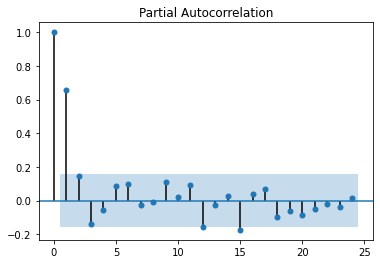

```python
#https://www.statsmodels.org/stable/generated/statsmodels.graphics.tsaplots.plot_pacf.html?highlight=plot_pacf#statsmodels.graphics.tsaplots.plot_pacf
sm.graphics.tsa.plot_pacf(df.log_value.squeeze(), lags=24, method="ywm")
plt.show()
```

Jeśli wypustka do 10 wypustki wystaje ponad poziom istotności, to warto ją zaliczyć. Poziom będzie potem i tak redukowany w analizie od ogółu do szczegółu.

## ANALIZA STACJONARNOŚCI - testy formalne

```python
#Set timestamp as index
df.set_index('timestamp', inplace=True)
```

### Dickey-Fuller test

```python
df
```

| timestamp | log_value |
| --- | --- |
| 31.10.2008 | 6.907755 |
| 28.11.2008 | 6.907755 |
| 30.12.2008 | 6.241250 |
| 28.01.2009 | 5.723585 |
| 20.02.2009 | 4.768564 |
| ... | ... |
| 26.02.2021 | 5.898527 |
| 31.03.2021 | 5.966019 |
| 30.04.2021 | 5.846815 |
| 28.05.2021 | 5.758902 |
| 30.06.2021 | 5.535364 |

153 rows × 1 columns

## Na podstawie analizy graficznej, przechodzę do rozszerzonego testu Dickey-Fullera. Python nie posiada podstawowego testu Dickey-Fullera.

```python
df.log_value
```

```
timestamp
31.10.2008    6.907755
28.11.2008    6.907755
30.12.2008    6.241250
28.01.2009    5.723585
20.02.2009    4.768564
                ...
26.02.2021    5.898527
31.03.2021    5.966019
30.04.2021    5.846815
28.05.2021    5.758902
30.06.2021    5.535364
Name: log_value, Length: 153, dtype: float32
```

### H0: Szereg jest niestacjonarny.

#### Ponieważ Test Statistic (-2.887) jest mniejsze od wartości krytycznej(-2.882), to odrzucam hipotezę zerową.

#### Można też powiedzieć, że p-value (4,7%) jest mniejsze od założonego poziomu istotności (5%), dlatego odrzucamy hipotezę zerową.

#### W dalszych obliczeniach muszę konsekwentie przyjmować wartość krytyczną 5%.

```python
?adfuller
```

```python
from statsmodels.tsa.stattools import adfuller

def adf_test(timeseries):
    print("Results of Dickey-Fuller Test:")
    dftest = adfuller(timeseries, regression = "c", autolag="AIC")
    dfoutput = pd.Series(
        dftest[0:4],
        index=[
            "Test Statistic",
            "p-value",
            "#Lags Used",
            "Number of Observations Used",
        ],
    )
    for key, value in dftest[4].items():
        dfoutput["Critical Value (%s)" % key] = value
    print(dfoutput)
```

```python
adf_test(df.log_value.squeeze())
```

```
Results of Dickey-Fuller Test:
Test Statistic                  -2.887729
p-value                          0.046794
#Lags Used                      14.000000
Number of Observations Used    138.000000
Critical Value (1%)             -3.478648
Critical Value (5%)             -2.882722
Critical Value (10%)            -2.578065
dtype: float64
```

## Po wykonaniu testu Dickeya-Fullera, należy też wykonać też Breucha Godfreya. Natomiast w pythonie jest jedynie test rozszerzony Augmented-Dickey-Fuller, który działa automatycznie (zawiera też w swojej implementacji test Breucha-Godfreya).

### Test Breucha-Godfreya sprawdza autokorelację reszt w modelu.

https://www.kaggle.com/nholloway/deconstructing-arima

## TEST KPSS - można go stosować oprócz testu Dickeya-Fullera

### H0: Analizowana zmienna jest stacjonarna.

#### p-value(10%) jest większa niż poziom istotności 5%, a zatem brak podstaw do odrzucenia hipotezy zerowej.

#### Wartość Test Statistic 0.13 jest mniejsza od poziomu istotności 5% (0.463), a zatem hipotezy zerowej nie można odrzucić.

```python
from statsmodels.tsa.stattools import kpss

def kpss_test(timeseries):
    print("Results of KPSS Test:")
    kpsstest = kpss(timeseries, regression="c", nlags="auto")
    kpss_output = pd.Series(
        kpsstest[0:3], index=["Test Statistic", "p-value", "Lags Used"]
    )
    for key, value in kpsstest[3].items():
        kpss_output["Critical Value (%s)" % key] = value
    print(kpss_output)
```

```python
kpss_test(df.log_value.squeeze())
```

```
Results of KPSS Test:
Test Statistic           0.131737
p-value                  0.100000
Lags Used                7.000000
Critical Value (10%)     0.347000
Critical Value (5%)      0.463000
Critical Value (2.5%)    0.574000
Critical Value (1%)      0.739000
dtype: float64
```

## Po wykonaniu testów formalnych potwierdzono, że szereg jest stacjonarny.

# Na podstawie analizy graficznej stwierdzamy, że nasz model to ARIMA(1,0,3)

- ARIMA(p,d,q):
- p od wykresu PACF
- d to ilość różnicowań (first difference)
- q od wykresu ACF

## Test Ljunga-Boxa oraz Boxa-Pierce'a, czyli sprawdzenie autokorelacji reszt.

https://www.statsmodels.org/stable/generated/statsmodels.stats.diagnostic.acorr_ljungbox.html

Test Ljunga-Boxa (dla residuals)

```python
data = df
res = sm.tsa.ARIMA(data["log_value"], (1,0,3)).fit(disp=-1)
sm.stats.acorr_ljungbox(res.resid, lags=[24], return_df=True)
```

|  | lb_stat | lb_pvalue |
| --- | --- | --- |
| 24 | 23.873686 | 0.468839 |

Test Boxa-Pierce'a: set parameter boxpierce = True

```python
data = df
res = sm.tsa.ARIMA(data["log_value"], (1,0,3)).fit(disp=-1)
sm.stats.acorr_ljungbox(res.resid, lags=[24], return_df=True, boxpierce = True)
```

|  | lb_stat | lb_pvalue | bp_stat | bp_pvalue |
| --- | --- | --- | --- | --- |
| 24 | 23.873686 | 0.468839 | 21.900176 | 0.585225 |

- H0: Reszty z modelu są białym szumem.
- Wartości p-value z obu testów (0.47 oraz 0.58) są większe od poziomu istotności p-value 5%, a zatem brak podstaw do odrzucenia hipotezy zerowej. Reszty są białym szumem - jest to stan pożądany. Jeśli reszty są białym szumem, to nie są skorelowane (brak autokorelacji). Biały szum to ciąg niezaleznych zmiennych losowych.

```python
#data = df
#res = sm.tsa.ARIMA(data["log_value"], (1,0,3)).fit(disp=-1)
#sm.stats.diagnostic.acorr_breusch_godfrey(res.resid, nlags=24)
```

### Teraz wykonuję wykresy ACF i PACF dla reszt z modelu, a nie dla samego modelu.

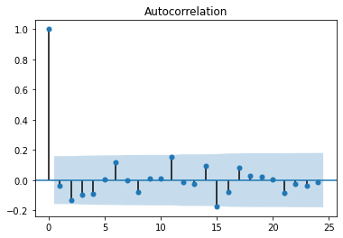

```python
#POPRAWNY WYKRES
sm.graphics.tsa.plot_acf(res.resid, lags=24) #residuals
plt.show()
#Pierwszą wypustkę pomijamy, bo to korelacja zmiennej sama ze sobą
```

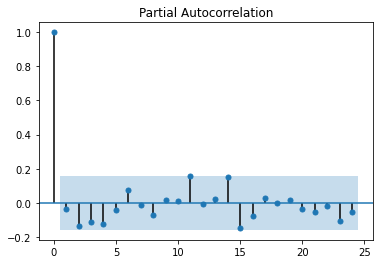

```python
sm.graphics.tsa.plot_pacf(res.resid, lags=24, method="ywm")
plt.show()
```

Wykresy korelogramów potwierdzają to, co testy formalne - czyli, że reszty z modelu przybliżają proces białego szumu. Wszystkie wypustki powinny mieścić się w okolicach zera.

## ARIMA

```python
data.log_value
```

```
timestamp
31.10.2008    6.907755
28.11.2008    6.907755
30.12.2008    6.241250
28.01.2009    5.723585
20.02.2009    4.768564
                ...
26.02.2021    5.898527
31.03.2021    5.966019
30.04.2021    5.846815
28.05.2021    5.758902
30.06.2021    5.535364
Name: log_value, Length: 153, dtype: float32
```

```python
#ANALIZA OD OGÓŁU DO SZCZEGÓŁU
from statsmodels.tsa.arima_model import ARIMA
#https://www.machinelearningplus.com/time-series/arima-model-time-series-forecasting-python/

model = ARIMA(data.log_value, order=(1,0,3))
model_fit = model.fit()
#alternatywnie w jednej linii: arima111 = ARIMA(data.diff_value, order=(1,1,1)).fit()
print(model_fit.summary())
#save model as arima111
arima103 = model
```

```
                              ARMA Model Results
==============================================================================
Dep. Variable:              log_value   No. Observations:                  153
Model:                     ARMA(1, 3)   Log Likelihood                   2.330
Method:                       css-mle   S.D. of innovations              0.237
Date:                Sat, 02 Oct 2021   AIC                              7.341
Time:                        14:48:35   BIC                             25.524
Sample:                             0   HQIC                            14.727

===================================================================================
                      coef    std err          z      P>|z|      [0.025      0.975]
-----------------------------------------------------------------------------------
const               5.2140      0.097     53.497      0.000       5.023       5.405
ar.L1.log_value     0.7423      0.131      5.663      0.000       0.485       0.999
ma.L1.log_value    -0.1414      0.153     -0.925      0.355      -0.441       0.158
ma.L2.log_value     0.3806      0.096      3.981      0.000       0.193       0.568
ma.L3.log_value     0.0580      0.110      0.527      0.598      -0.158       0.274
                                    Roots
=============================================================================
                  Real          Imaginary           Modulus         Frequency
-----------------------------------------------------------------------------
AR.1            1.3472           +0.0000j            1.3472            0.0000
MA.1            0.3336           -1.5079j            1.5444           -0.2153
MA.2            0.3336           +1.5079j            1.5444            0.2153
MA.3           -7.2272           -0.0000j            7.2272           -0.5000
-----------------------------------------------------------------------------
```

```python
#Trzeba zmniejszyć q (ma) o jeden stopień
model = ARIMA(data.log_value, order=(1,0,2))
model_fit = model.fit()
print(model_fit.summary())
arima102 = model
```

```
                              ARMA Model Results
==============================================================================
Dep. Variable:              log_value   No. Observations:                  153
Model:                     ARMA(1, 2)   Log Likelihood                   2.189
Method:                       css-mle   S.D. of innovations              0.237
Date:                Sat, 02 Oct 2021   AIC                              5.622
Time:                        14:51:59   BIC                             20.774
Sample:                             0   HQIC                            11.777

===================================================================================
                      coef    std err          z      P>|z|      [0.025      0.975]
-----------------------------------------------------------------------------------
const               5.2227      0.105     49.694      0.000       5.017       5.429
ar.L1.log_value     0.7856      0.086      9.117      0.000       0.617       0.954
ma.L1.log_value    -0.1980      0.096     -2.054      0.040      -0.387      -0.009
ma.L2.log_value     0.3712      0.093      4.002      0.000       0.189       0.553
                                    Roots
=============================================================================
                  Real          Imaginary           Modulus         Frequency
-----------------------------------------------------------------------------
AR.1            1.2729           +0.0000j            1.2729            0.0000
MA.1            0.2667           -1.6195j            1.6413           -0.2240
MA.2            0.2667           +1.6195j            1.6413            0.2240
-----------------------------------------------------------------------------
```

Obecnie wszystkie parametry są istotne statystycznie (p-value < 5%).

### Z uwagi na brak funkcji likelihood ratio w pythonie, aby sprawdzić czy wykonany przez nas krok był poprawny, należy sprawdzić w tabelce (ARMA Model Results) wartości Log Likelihood:

- L1 jako wartość wyjściową (zawsze z pierwszej tabelki, jest to wartość stała)
- L2 jako wartość po wykonaniu pewnego zmniejszenia o jeden stopień (ta wartość będzie się zmieniała dla kazdego zmniejszenia).

```python
#Z R studio
#teststat<- 2*(as.numeric(logLik(arima211))-as.numeric(logLik(arima111)))
#teststat
```

```python
#ANALIZA OD OGÓŁU DO SZCZEGÓŁU
from scipy.stats.distributions import chi2

L1 = 2.330
L2 = 2.189

def likelihood_ratio(L1, L2):
    return 2*(L1-L2)

LR = likelihood_ratio(L1,L2)
print(LR) #ta wartość jest potrzebna tylko do obliczeń
p = chi2.sf(LR, 1) #argumenty: likelihood ratio, stopień swobody
print(p)
print('p: %.30f' % p )
```

```
0.28200000000000003
0.5953933323247131
p: 0.595393332324713142611471994314
```

### H0: zmienna jest statystycznie nieistotna.

Ponieważ p-value = 60% jest większe od poziomu istotności 5%, to brak podstaw do odrzucenia hipotezy zerowej. A zatem zmienna jest statystycznie nieistotna. Czyli mielismy prawo wykonać ten krok.

Stopień swobody jest to ilość restrykcji narzucona w modelu. Zawsze na początku zakładamy, że zmienna q3 = 0 (jest statystycznie nieistotna) i patrzymy na ilość równań. Jeśli jedna zmienna była nieistotna, to stopień swobody=1. Gdyby jeszcze np. q2 = 0, czyli druga zmienna jest statystycznie nieistotna, to stopień swobody=2.

### Na ten moment wszystkie pozostałe zmienne są statystycznie istotne. A zatem nie trzeba wykonywać dalszych kroków.

```python
#POSSIBLE ARIMA COMBINATIONS - ANALIZA AUTOMATYCZNA
#Warto wziąć nieco większe zakresy - wtedy analiza automatyczna może dać inne, lepsze wyniki
for p in range(0,4):
    for d in range(0,1):
        for q in range(0,4):
            results = ARIMA(data.log_value, order=(p, d, q)).fit()
            print('ARIMA({}, {}, {}) - AIC:{} - BIC:{} - HQIC:{}'.format(p, d, q, results.aic, results.bic, results.hqic))
```

```
ARIMA(0, 0, 0) - AIC:130.799931840793 - BIC:136.86080768357786 - HQIC:133.2619600097091
ARIMA(0, 0, 1) - AIC:78.14667882628407 - BIC:87.23799259046137 - HQIC:81.83972107965822
ARIMA(0, 0, 2) - AIC:42.38930334137041 - BIC:54.51105502694015 - HQIC:47.313359679202605
```

```
ARIMA(0, 0, 3) - AIC:17.25521543439919 - BIC:32.407405041361365 - HQIC:23.410285856689438
ARIMA(1, 0, 0) - AIC:23.1999117357214 - BIC:32.29122549989871 - HQIC:26.89295398909555
```

```
ARIMA(1, 0, 1) - AIC:17.008365321917324 - BIC:29.130117007487065 - HQIC:21.932421659749522
```

```
ARIMA(1, 0, 2) - AIC:5.621767223032066 - BIC:20.77395682999424 - HQIC:11.776837645322313
```

```
ARIMA(1, 0, 3) - AIC:7.340919357487564 - BIC:25.523546885842176 - HQIC:14.727003864235861
ARIMA(2, 0, 0) - AIC:11.930516009176472 - BIC:24.052267694746213 - HQIC:16.85457234700867
```

```
ARIMA(2, 0, 1) - AIC:12.073347272667831 - BIC:27.225536879630006 - HQIC:18.22841769495808
```

```
ARIMA(2, 0, 2) - AIC:7.375997513157415 - BIC:25.558625041512027 - HQIC:14.762082019905712
```

```
ARIMA(2, 0, 3) - AIC:9.318779116109681 - BIC:30.53184456585673 - HQIC:17.935877707316028
```

```
ARIMA(3, 0, 0) - AIC:10.225808218573945 - BIC:25.37799782553612 - HQIC:16.380878640864193
```

```
ARIMA(3, 0, 1) - AIC:9.943513745245582 - BIC:28.126141273600194 - HQIC:17.32959825199388
```

```
ARIMA(3, 0, 2) - AIC:8.993626623483976 - BIC:30.206692073231025 - HQIC:17.610725214690323
```

```
ARIMA(3, 0, 3) - AIC:10.703795281100895 - BIC:34.94729865224038 - HQIC:20.55190795676529
```

## ZAUTOMATYZOWAĆ DLA DATAFRAME - sortuj

[output not shown]

- Najniższe AIC: ARIMA(1, 0, 2) - AIC:5.621767223032066
- Najniższe BIC: ARIMA(1, 0, 2) - BIC:20.77395682999424
- Najniższe HQIC: ARIMA(1, 0, 2) - HQIC:11.776837645322313

## Analiza automatyczna wskazuje na to samo, co analiza od ogółu do szczegółu - najlepsze (czyli najniższe) wartości AIC, BIC i HQIC ma ARIMA(1,0,2)

### Gdyby te wskaźniki się między sobą różniły, wykonujemy predykcję dla obu (nie odrzucamy jakiegoś z modeli.) i na podstawie miar błędów predykcji (MAPE, AMAPE, MSE) wybieramy najlepszy model.

## Fitting ARIMA model

```python
data.log_value
```

```
timestamp
31.10.2008    6.907755
28.11.2008    6.907755
30.12.2008    6.241250
28.01.2009    5.723585
20.02.2009    4.768564
                ...
26.02.2021    5.898527
31.03.2021    5.966019
30.04.2021    5.846815
28.05.2021    5.758902
30.06.2021    5.535364
Name: log_value, Length: 153, dtype: float32
```

```python
df
```

[output not shown]

153 rows × 2 columns

```python
df['log_value'][:150]
```

[output not shown]

```python
df['log_value'][150:]
```

```
150    5.846815
151    5.758902
152    5.535364
Name: log_value, dtype: float32
```

## Zgodnie z nieformalną regułą powinnismy wziąć okres out-of-sample jako max(p,q), ale biorę okres trochę dłuższy, aby porównać jakość predykcji.

```python
# Create Training and Test
#Jako zbiór treningowy i testowy używamy danych zlogarytmowanych, ale nie po pierwszej różnicy, gdyż first difference
#była potrzebna tylko do analizy - do ustalenia modelu
train = df['log_value'][:150]
test = df['log_value'][150:]
```

```python
train, test
```

```
(0      6.907755
 1      6.907755
 2      6.241250
 3      5.723585
 4      4.768564
          ...
 145    5.262949
 146    5.159055
 147    5.966787
 148    5.898527
 149    5.966019
 Name: log_value, Length: 150, dtype: float32,
 150    5.846815
 151    5.758902
 152    5.535364
 Name: log_value, dtype: float32)
```

```python
model = ARIMA(train, order=(1, 0, 2))
fitted = model.fit(disp=-1)
```

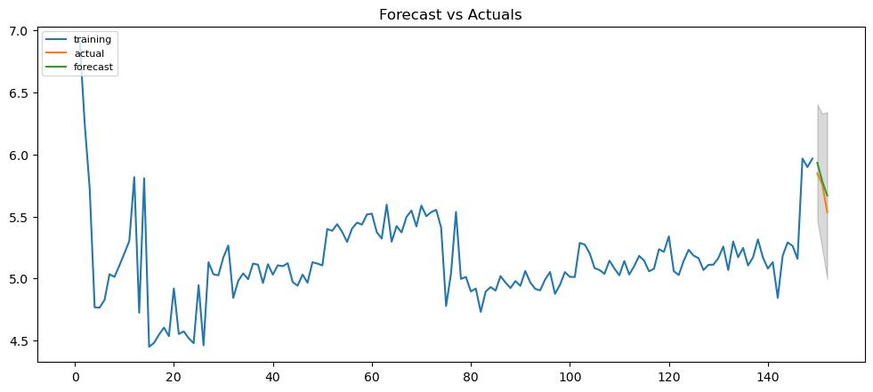

```python
# Forecast
fc, se, conf = fitted.forecast(3, alpha=0.05)  # 3 okresy do przodu, 95% conf
#se - błąd standardowy
#fc - forecast
#conf - poziom ufności

# Make as pandas series
fc_series = pd.Series(fc, index=test.index)
lower_series = pd.Series(conf[:, 0], index=test.index)
upper_series = pd.Series(conf[:, 1], index=test.index)

# Plot
plt.figure(figsize=(12,5), dpi=100)
plt.plot(train, label='training')
plt.plot(test, label='actual')
plt.plot(fc_series, label='forecast')
plt.fill_between(lower_series.index, lower_series, upper_series,
                 color='k', alpha=.15)
plt.title('Forecast vs Actuals')
plt.legend(loc='upper left', fontsize=8)
plt.show()
```

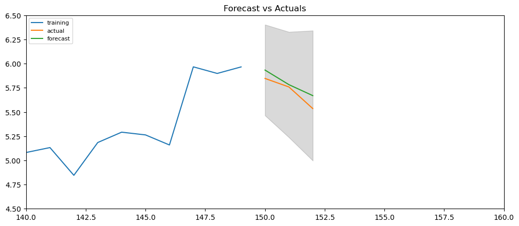

```python
# Plot
plt.figure(figsize=(12,5), dpi=100)
plt.plot(train, label='training')
plt.plot(test, label='actual')
plt.plot(fc_series, label='forecast')
plt.fill_between(lower_series.index, lower_series, upper_series,
                 color='k', alpha=.15)
plt.title('Forecast vs Actuals')
plt.legend(loc='upper left', fontsize=8)
plt.xlim([140, 160])
plt.ylim([4.5, 6.5])
plt.show()
```

# TODO: połącz lukę - punkty między 149 a 150. Ta luka wynika prawdopodobnie z tego, że python traktuje zbiór in-sample i out-of-sample jako 2 osobne datasety.

```python
#MAPE, MAE, RMSE
from statsmodels.tsa.stattools import acf
# Accuracy metrics
def forecast_accuracy(forecast, actual):
    mape = np.mean(np.abs(forecast - actual)/np.abs(actual))  # MAPE
    me = np.mean(forecast - actual)             # ME
    mae = np.mean(np.abs(forecast - actual))    # MAE
    mpe = np.mean((forecast - actual)/actual)   # MPE
    rmse = np.mean((forecast - actual)**2)**.5  # RMSE
    corr = np.corrcoef(forecast, actual)[0,1]   # corr
    mins = np.amin(np.hstack([forecast[:,None],
                              actual[:,None]]), axis=1)
    maxs = np.amax(np.hstack([forecast[:,None],
                              actual[:,None]]), axis=1)
    minmax = 1 - np.mean(mins/maxs)             # minmax
    acf1 = acf(fc-test)[1]                      # ACF1
    return({'mape':mape, 'me':me, 'mae': mae,
            'mpe': mpe, 'rmse':rmse, 'acf1':acf1,
            'corr':corr, 'minmax':minmax})

forecast_accuracy(fc, test.values)
```

```
{'mape': 0.014372388004415641,
 'me': 0.08140187848470444,
 'mae': 0.08140187848470444,
 'mpe': 0.014372388004415641,
 'rmse': 0.09301982859427507,
 'acf1': -0.5442024817519698,
 'corr': 0.9470618589256501,
 'minmax': 0.014104595492891892}
```

Niskie miary błędów:

- MAPE - ok. 1,5%
- MAE - około 8%
- RMSE - około 9%

## NOTES

- Podczas wykonywania prognozy trzeba zwracać uwagę na elementy formalne (testy dickeya-fullera, badanie stacjonarności, autokorelacji).
- Procedura Boxa-Jenkinsa mówi, co po kolei wykonywać podczas przeprowadzania prognozy.
- Zazwyczaj przy zmiennych giełdowych nie powinno być sezonowości. Gdyby się pojawiła, należałoby wykonać model SARIMA. Sezonowość wykrywamy podczas dekompozycji szeregu (widać ją też po wykresie samego szeregu).